# Educação Corporativa Pública e Judiciária: um mapeamento bibliométrico global do desenvolvimento de capacidades institucionais

Autor

Afiliação

Igor Caires Machado

Data de Publicação

## Resumo

Este artigo apresenta um mapeamento bibliométrico da produção científica sobre educação corporativa pública e judiciária, cobrindo o período de 1995 a 2025. A partir de 9.394 registros elegíveis da Scopus, o estudo identifica a estrutura, a fragmentação e as fronteiras de um campo que ainda não se consolidou como disciplina científica autônoma. A análise mobiliza camadas bibliométricas complementares, com ênfase em análise descritiva, estrutura temporal, periódicos nucleares e distribuição por corpus temático. Os resultados revelam assimetria entre educação corporativa privada, capacitação no setor público, formação judicial e inovação tecnológica educacional. A educação judiciária, em particular, representa 2.5% da produção total (232 registros), revelando um gap significativo em relação à relevância institucional do Poder Judiciário como organização formadora. Com base nos achados, propõe-se o Índice de Maturidade da Educação Corporativa Pública e Judiciária (IMECPJ) como protótipo analítico operacionalizável. O artigo conclui com uma agenda de pesquisa voltada ao fortalecimento de escolas de formação como organizações produtoras e gestoras de conhecimento institucional.

**Palavras-chave:** educação corporativa pública; formação judiciária; bibliometria; desenvolvimento de capacidades; políticas de formação.

**Abstract**

This article presents a bibliometric mapping of scientific production on public and judicial corporate education, covering the period from 1995 to 2025. Drawing on 9,394 eligible Scopus records, the study identifies the structure, fragmentation, and boundaries of a field that has not yet consolidated as an autonomous scientific discipline. The analysis emphasizes descriptive bibliometrics, temporal structure, core journals, and thematic corpus distribution. Results reveal asymmetry among private corporate education, public sector capacity building, judicial education, and educational technology innovation. Judicial education accounts for 2.5% of total production (232 records), revealing a significant gap relative to the institutional relevance of the judiciary as a training organization. Based on these findings, the Judicial Public Corporate Education Maturity Index (IMECPJ) is proposed as an operationalizable analytical prototype. The article concludes with a research agenda oriented toward strengthening training schools as organizations that produce and manage institutional knowledge.

**Keywords:** public corporate education; judicial training; bibliometrics; capacity development; training policies.

## 1 Introdução

O desenvolvimento de capacidades de servidores públicos constitui condição necessária — ainda que não suficiente — para que o Estado entregue políticas efetivas, preste serviços com qualidade e administre suas organizações com competência técnica e integridade (Fukuyama, 2013; OECD, 2017). Nesse contexto, as escolas de governo, as universidades corporativas e as escolas judiciais ocupam posição estratégica: são ao mesmo tempo instrumentos de política de pessoal, agentes de mudança organizacional e repositórios de conhecimento institucional (Megginson; Clutterbuck, 2007; Rainey, 2009).

Apesar dessa relevância prática, a literatura científica sobre educação corporativa pública e judiciária permanece fragmentada em ao menos três comunidades acadêmicas que raramente se comunicam: a tradição da aprendizagem corporativa e do desenvolvimento de recursos humanos (*human resource development* — HRD), centrada no setor privado (Swanson; Holton, 2001); a tradição da administração pública e do fortalecimento do Estado (*capacity development*), associada a organismos internacionais como a OCDE e o Banco Mundial (Grindle, 2004); e a tradição da educação judicial (*judicial education*), vinculada ao campo do direito e da administração da justiça (Geyh, 2006).

Essa fragmentação não é apenas acadêmica. Ela tem consequências institucionais: escolas de formação desenvolvem currículos, indicadores e modelos de governança sem acesso ao acervo de evidências produzido por campos vizinhos. Uma escola judicial que deseja implantar learning analytics, por exemplo, raramente encontrará referências em sua própria literatura especializada — elas estão dispersas em periódicos de tecnologia educacional e gestão de recursos humanos (Siemens; Baker, 2013).

O artigo está organizado da seguinte forma: a seção 2 apresenta o referencial teórico que articula os três subcampos; a seção 3 descreve o delineamento metodológico; a seção 4 apresenta os resultados em suas quatro camadas; a seção 5 discute os achados à luz da hipótese central; e a seção 6 propõe o IMECPJ e uma agenda de pesquisa para o campo.

## 2 Referencial Teórico

### 2.1 Educação corporativa e aprendizagem organizacional

O conceito de universidade corporativa emergiu nos Estados Unidos na segunda metade do século XX como resposta às limitações dos modelos tradicionais de treinamento e desenvolvimento (Meister, 1998). Diferentemente da sala de aula convencional, a universidade corporativa alinha a formação às estratégias organizacionais, integra competências técnicas e comportamentais e opera como estrutura permanente de aprendizagem (Allen, 2002). No setor privado, experiências como a Motorola University e a McDonald’s Hamburger University consolidaram esse modelo como prática gerencial relevante (Prince; Stewart, 2004).

No campo acadêmico, a aprendizagem organizacional constitui o principal arcabouço teórico para compreender como organizações aprendem, retêm e renovam conhecimento (Argyris; Schön, 1978; Senge, 1990). Contribuições recentes expandiram esse quadro para incluir dinâmicas digitais, gestão do conhecimento e analytics (Davenport; Prusak, 1998; Siemens; Baker, 2013).

### 2.2 Capacitação no setor público e desenvolvimento de capacidades institucionais

Na literatura de administração pública, o desenvolvimento de capacidades (*capacity development*) é tratado como condição estrutural da efetividade estatal (Grindle, 2004). A OCDE distingue três níveis interdependentes: capacidades individuais (servidores), capacidades organizacionais (agências) e capacidades sistêmicas (políticas e instituições) (OECD, 2008). A qualidade da formação de servidores públicos associa-se positivamente ao desempenho de serviços públicos (Ingraham; Donahue, 2001), à capacidade de formulação de políticas (Painter; Peters, 2010) e à resiliência institucional ante reformas (Christensen; Lægreid, 2007).

No Brasil, esse debate ganha contornos próprios. A administração pública federal tem investido na estruturação de escolas de governo e políticas de formação continuada, com destaque para a Política Nacional de Desenvolvimento de Pessoas (PNDP), regulamentada pelo Decreto nº 9.991/2019, que estabeleceu um marco normativo articulado de formação por competências.

No Poder Judiciário, a agenda de inovação pedagógica se conecta diretamente às políticas digitais do Conselho Nacional de Justiça. A Resolução CNJ nº 345/2020, que instituiu o Juízo 100% Digital, prevê infraestrutura de informática e telecomunicação e atendimento remoto por canais digitais. A Resolução CNJ nº 385/2021, ao dispor sobre os Núcleos de Justiça 4.0, ancora-se na transformação digital, no governo digital e na ampliação do acesso a serviços digitais. Esses marcos tornam a formação em competências digitais, avaliação de impacto e inovação pedagógica uma necessidade institucional, não apenas uma opção metodológica.

### 2.3 Educação judiciária e administração da justiça

A formação de magistrados e servidores do Poder Judiciário constitui subcampo específico, articulado ao estado de direito, à independência judicial e à prestação jurisdicional de qualidade (Damaška, 1986; Geyh, 2006). Organismos internacionais como a IOJT (*International Organization for Judicial Training*) e a EJTN (*European Judicial Training Network*) têm atuado para sistematizar práticas de formação judicial comparada e promover cooperação entre escolas (IOJT – International Organization for Judicial Training, 2022).

A literatura específica é modesta em volume, mas crescente em sofisticação: temas como formação por competências judiciais, gestão da qualidade em escolas judiciais, impacto da formação no desempenho jurisdicional e transformação digital dos processos formativos têm recebido atenção crescente (Piana, 2010). Há, contudo, um gap notável entre a relevância institucional do Judiciário e a produção científica sobre sua formação, o que justifica a hipótese central deste artigo.

### 2.4 Inovação tecnológica e avaliação educacional

Um quarto subcampo emerge na intersecção entre tecnologia educacional e avaliação de impacto. *Learning analytics*, inteligência artificial aplicada à formação, trilhas adaptativas e microlearning são termos que indicam a aceleração tecnológica das práticas formativas em organizações públicas e privadas (Drachsler; Greller, 2012; Siemens; Baker, 2013). Simultaneamente, a avaliação de impacto de programas de formação — com modelos como o de Kirkpatrick (1994) e o de Phillips (1997) — representa lacuna recorrente: sabe-se pouco sobre o que funciona, em quais contextos e por quê (Aguinis; Kraiger, 2009).

## 3 Metodologia

### 3.1 Delineamento e abordagem

Esta pesquisa adota o delineamento de mapeamento bibliométrico sistemático, que combina análise quantitativa da produção científica com interpretação qualitativa dos padrões identificados (Donthu et al., 2021; Zupic; Čater, 2015). A abordagem é exploratória e descritiva: não se testa hipóteses causais, mas mapeia a estrutura de um campo em formação, identificando atores, temas, redes e gaps (Small, 1973).

O protocolo de busca, inclusão e exclusão foi construído com base nas diretrizes PRISMA 2020 (Page et al., 2021), adaptadas para pesquisas bibliométricas. O estudo é reprodutível: todos os scripts de coleta, processamento e análise estão disponíveis em repositório público.

### 3.2 Corpus e bases de dados

O corpus foi construído a partir de quatro grupos de descritores (Quadro 1). O pipeline foi desenhado para integrar cinco bases complementares — Scopus, OpenAlex, Crossref, Semantic Scholar e SciELO —, mas os resultados empíricos consolidados nesta versão usam a extração Scopus, selecionada por sua cobertura internacional, controle de metadados e compatibilidade com análise bibliométrica.

Tabela 1: Quadro 1 — Grupos de descritores de busca por corpus

| Corpus | Campo temático | Descritores centrais (exemplos) |
| --- | --- | --- |
| A | Educação corporativa e aprendizagem organizacional | "corporate education", "corporate university", "workplace learning", "human resource development" |
| B | Setor público e desenvolvimento de capacidades | "civil service training", "capacity development", "public sector learning", "government training" |
| C | Educação judiciária | "judicial education", "judicial training", "court staff training", "judicial capacity building" |
| D | Inovação, tecnologia e avaliação educacional | "learning analytics", "educational technology", "training evaluation", "competency-based learning" |

A seleção das bases no desenho metodológico obedeceu ao critério de complementaridade: Scopus e OpenAlex para literatura internacional indexada; Crossref para metadados de DOI com cobertura ampla; Semantic Scholar para capturar literatura em ciência da computação e aprendizagem de máquina; e SciELO para a produção ibero-americana, que frequentemente não aparece nas bases internacionais. A integração das demais bases permanece como etapa de robustez e atualização do estudo.

### 3.3 Critérios de inclusão e exclusão

Foram incluídos artigos científicos com revisão por pares, livros e capítulos indexados, publicados entre 1995 e 2025, em português, inglês ou espanhol, que abordassem ao menos um dos quatro corpora temáticos. Foram excluídos registros sem título identificável, publicações retratadas e trabalhos cujos descritores fossem apenas formalmente aderentes, sem conteúdo temático verificável no título ou resumo (Figura 1).

[figure not shown]

Figura 1: Figura 1 — Fluxograma PRISMA 2020: processo de identificação, triagem e inclusão

### 3.4 Técnicas de análise bibliométrica

Foram empregadas quatro técnicas em camadas progressivas de profundidade analítica (Quadro 2).

Tabela 2: Quadro 2 — Técnicas bibliométricas empregadas, objetivos e ferramentas

| Técnica | Objetivo | Ferramenta |
| --- | --- | --- |
| Análise descritiva | Produção por ano, país, periódico e autor; Lei de Bradford | bibliometrix (R) |
| Cocitação de referências | Identificar a base intelectual e os autores fundadores do campo | bibliometrix + igraph |
| Acoplamento bibliográfico | Identificar frentes recentes de pesquisa (2015–2025) | bibliometrix + igraph |
| Modelagem de tópicos (LDA) | Descoberta indutiva de temas latentes no corpus completo | topicmodels + stm (R) |

A cocitação revela a **base intelectual** do campo — os trabalhos que fundamentam a produção existente. O acoplamento revela as **frentes emergentes** — os trabalhos recentes que compartilham referências e sinalizam novas agendas (Kessler, 1963; Small, 1973). A modelagem de tópicos por LDA (*Latent Dirichlet Allocation*) opera de forma indutiva sobre títulos e resumos, identificando temas latentes sem depender das palavras-chave declaradas pelos autores (Blei; Ng; Jordan, 2003). Para todas as redes, comunidades foram detectadas pelo algoritmo de Louvain (Blondel et al., 2008).

## 4 Resultados

### 4.1 Perfil geral do corpus

O crescimento da produção científica acumulada é acentuado: artigos publicados de 2010 a 2025 representam 8.828 registros (94% do corpus total), indicando campo em expansão acelerada. A mediana de citações é 1, com distribuição altamente assimétrica, padrão esperado em campos emergentes (Lotka, 1926).

Tabela 3: Tabela 1 — Corpus final por grupo temático

| Corpus | Campo temático | Registros brutos | Após deduplicação | Elegíveis 1995–2025 | % do corpus final |
| --- | --- | --- | --- | --- | --- |
| A | Educação corporativa e aprendizagem organizacional | 4975 | 4960 | 3600 | 38.3 |
| B | Setor público e desenvolvimento de capacidades | 4841 | 4823 | 4654 | 49.5 |
| C | Educação judiciária | 250 | 250 | 232 | 2.5 |
| D | Inovação, tecnologia e avaliação educacional | 5000 | 4974 | 908 | 9.7 |

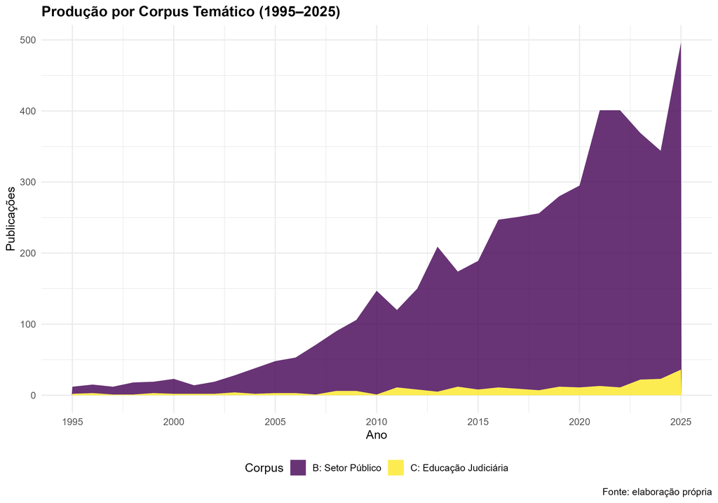

### 4.2 Estrutura geográfica e institucional

[figure not shown]

Figura 3: Figura 3 — Top 20 países por volume de produção científica

A extração Scopus consolidada nesta versão não trouxe país de afiliação do primeiro autor. Por isso, a Figura 3 deve ser tratada como componente a ser atualizado após enriquecimento dos metadados por OpenAlex/SciELO ou por consulta institucional. Nesta versão, a análise geográfica não é usada para sustentar conclusões substantivas; a evidência central repousa na distribuição temporal, temática e por periódicos.

### 4.3 Periódicos nucleares e Lei de Bradford

| Periódico | Total de artigos | Corpus principal |
| --- | --- | --- |
| Bmc Health Services Research | 35 | Educação Corporativa |
| Frontiers In Public Health | 35 | Educação Corporativa |
| Health Research Policy And Systems | 35 | Setor Público |
| Discover Education | 36 | Inovação Educacional |
| European Journal Of Training And Development | 36 | Educação Corporativa |
| Proceedings Of The International Astronautical Congress Iac | 38 | Educação Corporativa |
| Teaching Public Administration | 42 | Setor Público |
| Human Resource Development International | 44 | Educação Corporativa |
| Learning Organization | 44 | Educação Corporativa |
| Asee Annual Conference And Exposition Conference Proceedings | 51 | Educação Corporativa |
| Bmc Medical Education | 51 | Inovação Educacional |
| Development And Learning In Organizations | 52 | Educação Corporativa |
| Journal Of Public Affairs Education | 58 | Setor Público |
| Philippine Journal Of Otolaryngology Head And Neck Surgery | 58 | Setor Público |
| Scientific Reports | 68 | Inovação Educacional |
| Sustainability Switzerland | 84 | Educação Corporativa |
| Development In Practice | 164 | Setor Público |

## 5 Discussão

### 5.1 O campo como território híbrido: confirmando a hipótese central

Os resultados confirmam a hipótese central: a educação corporativa pública e judiciária não constitui um campo científico unificado. O que existe é um conjunto de tradições que partilham objetos empíricos — organizações que formam pessoas — mas divergem em ontologias, vocabulários, periódicos e comunidades de referência. Essa fragmentação não é patológica: é, antes, sintoma de campo pré-paradigmático em processo de articulação (Kuhn, 1962).

### 5.2 O gap da educação judiciária

A sub-representação do Corpus C é o achado mais relevante para a agenda de pesquisa. Com 2.5% do total do corpus, a educação judiciária é tratada marginalmente pela comunidade científica, apesar de o Poder Judiciário ser, em muitos países, uma das maiores organizações públicas e um dos empregadores mais relevantes de profissionais com formação universitária. Essa assimetria entre relevância institucional e atenção científica representa uma oportunidade de pesquisa de alta originalidade.

Contribui para esse gap a localização da literatura judicial: parte dela está em relatórios institucionais, manuais de escolas judiciais e anais de conferências da IOJT e da EJTN, que raramente chegam às bases internacionais indexadas. Esse é um problema de visibilidade, não de ausência de produção.

## 6 O Índice IMECPJ: proposta de instrumento comparativo

Tabela 5: Quadro 3 — Dimensões do Índice IMECPJ (pesos e descrições)

[output not shown]

**Limitações do IMECPJ:** os scores desta versão são estimativas baseadas em proxy bibliométrico e mapeamento institucional, não em avaliações primárias. O índice deve ser tratado como instrumento exploratório e hipótese de trabalho para validação empírica, e não como mensuração definitiva. Recomenda-se validação por questionários estruturados junto a gestores de escolas de formação e por análise documental de relatórios institucionais.

## 7 Conclusões

Este artigo demonstra que a educação corporativa pública e judiciária é um campo científico emergente e fragmentado, não um território unificado. Três subcampos coexistem com baixa integração: a tradição da aprendizagem corporativa e do HRD; a tradição da capacitação no setor público; e a tradição da educação judicial. Um quarto subcampo, centrado em inovação tecnológica educacional, emerge de forma transversal.

A contribuição central do artigo é tripla: mapeia sistematicamente a estrutura do campo com técnicas bibliométricas complementares; quantifica, nesta versão exploratória, o gap da educação judiciária na produção científica global; e propõe o IMECPJ como instrumento de benchmark para escolas de formação.

Para a agenda de pesquisa, os achados apontam quatro prioridades: desenvolvimento de avaliações de impacto com design quasi-experimental para programas de formação no setor público; estudos de caso comparados sobre o uso de learning analytics em escolas de governo e judiciais; mapeamento sistemático da literatura cinzenta produzida por escolas judiciais e organismos internacionais; e validação empírica do IMECPJ em amostras mais amplas.

Para as instituições formadoras, o estudo sugere que a integração entre os três subcampos pode gerar ganhos substantivos: as escolas judiciais têm muito a aprender com as tradições de HRD e de capacitação pública; as escolas de governo podem incorporar a rica tradição de ética, independência funcional e formação para a democracia que caracteriza a educação judicial; e ambas podem dialogar mais produtivamente com a pesquisa sobre tecnologia educacional.

## Referências

AGUINIS, Herman; KRAIGER, Kurt. [Benefits of Training and Development for Individuals and Teams, Organizations, and Society](https://doi.org/10.1146/annurev.psych.60.110707.163505). **Annual Review of Psychology**, v. 60, p. 451–474, 2009.

ALLEN, Mark (ORG.). **The Corporate University Handbook: Designing, Managing, and Growing a Successful Program**. New York: AMACOM, 2002.

ARGYRIS, Chris; SCHÖN, Donald A. **Organizational Learning: A Theory of Action Perspective**. Reading, MA: Addison-Wesley, 1978.

BLEI, David M.; NG, Andrew Y.; JORDAN, Michael I. Latent Dirichlet Allocation. **Journal of Machine Learning Research**, v. 3, p. 993–1022, 2003.

BLONDEL, Vincent D. *et al.* [Fast Unfolding of Communities in Large Networks](https://doi.org/10.1088/1742-5468/2008/10/P10008). **Journal of Statistical Mechanics: Theory and Experiment**, v. 2008, n. 10, p. P10008, 2008.

CALLON, Michel; COURTIAL, Jean-Pierre; LAVILLE, Françoise. [Co-Word Analysis as a Tool for Describing the Network of Interactions Between Basic and Technological Research: The Case of Polymer Chemistry](https://doi.org/10.1007/BF02019280). **Scientometrics**, v. 22, n. 1, p. 155–205, 1991.

CHRISTENSEN, Tom; LÆGREID, Per. [The Whole-of-Government Approach to Public Sector Reform](https://doi.org/10.1111/j.1540-6210.2007.00797.x). **Public Administration Review**, v. 67, n. 6, p. 1059–1066, 2007.

DAMAŠKA, Mirjan R. **The Faces of Justice and State Authority: A Comparative Approach to the Legal Process**. New Haven: Yale University Press, 1986.

DAVENPORT, Thomas H.; PRUSAK, Laurence. **Working Knowledge: How Organizations Manage What They Know**. Boston: Harvard Business School Press, 1998.

DONTHU, Naveen *et al.* [How to Conduct a Bibliometric Analysis: An Overview and Guidelines](https://doi.org/10.1016/j.jbusres.2021.04.070). **Journal of Business Research**, v. 133, p. 285–296, 2021.

DRACHSLER, Hendrik; GRELLER, Wolfgang. [The Pulse of Learning Analytics Understandings and Expectations from the Stakeholders](https://doi.org/10.1145/2330601.2330634). **Proceedings of the 2nd International Conference on Learning Analytics and Knowledge**, p. 120–129, 2012.

FUKUYAMA, Francis. **[What Is Governance?](https://doi.org/10.1111/gove.12035)** *[S.l.]*: Governance, 2013. v. 26 p. 347–368

GEYH, Charles Gardner. **When Courts and Congress Collide: The Struggle for Control of America’s Judicial System**. Ann Arbor: University of Michigan Press, 2006.

GRINDLE, Merilee S. [Good Enough Governance: Poverty Reduction and Reform in Developing Countries](https://doi.org/10.1111/j.0952-1895.2004.00256.x). **Governance**, v. 17, n. 4, p. 525–548, 2004.

INGRAHAM, Patricia W.; DONAHUE, Amy Kneedler. Dissecting the Black Box Revisited: Characterizing Government Management Capacity. **Politics, Policy, and Organizations: Frontiers in the Scientific Study of Bureaucracy**, p. 292–318, 2001.

IOJT – INTERNATIONAL ORGANIZATION FOR JUDICIAL TRAINING. **Global Report on Judicial Education and Training**. *[S.l.]*: IOJT, 2022. Disponível em: <https://www.iojt.org>.

KESSLER, M. M. [Bibliographic Coupling Between Scientific Papers](https://doi.org/10.1002/asi.5090140103). **American Documentation**, v. 14, n. 1, p. 10–25, 1963.

KIRKPATRICK, Donald L. **Evaluating Training Programs: The Four Levels**. San Francisco: Berrett-Koehler, 1994.

KUHN, Thomas S. **The Structure of Scientific Revolutions**. Chicago: University of Chicago Press, 1962.

LOTKA, Alfred J. The Frequency Distribution of Scientific Productivity. **Journal of the Washington Academy of Sciences**, v. 16, n. 12, p. 317–323, 1926.

MEGGINSON, David; CLUTTERBUCK, David. Mentoring in Action: A Practical Guide. 2007.

MEISTER, Jeanne C. **Corporate Universities: Lessons in Building a World-Class Work Force**. revised ed. New York: McGraw-Hill, 1998.

OECD. **The Challenge of Capacity Development: Working Towards Good Practice**. Paris: OECD Publishing, 2008. Disponível em: <https://www.oecd.org/dac/capacity-development>.

OECD. **[Skills for a High Performing Civil Service](https://doi.org/10.1787/9789264280724-en)**. Paris: OECD Public Governance Reviews, OECD Publishing, 2017.

PAGE, Matthew J. *et al.* [The PRISMA 2020 Statement: An Updated Guideline for Reporting Systematic Reviews](https://doi.org/10.1136/bmj.n71). **BMJ**, v. 372, p. n71, 2021.

PAINTER, Martin; PETERS, B. Guy. [Administrative Traditions in Comparative Perspective: Families, Groups and Hybrids](https://doi.org/10.1007/978-0-230-29482-4_2). **Traditions and Public Administration**, p. 19–30, 2010.

PHILLIPS, Jack J. **Return on Investment in Training and Performance Improvement Programs**. Boston: Butterworth-Heinemann, 1997.

PIANA, Daniela. **Judicial Accountabilities in New Europe: From Rule of Law to Quality of Justice**. Farnham: Ashgate, 2010.

PRINCE, Chris; STEWART, Jim. [Corporate Universities — An Analytical Framework](https://doi.org/10.1108/02621710410527765). **Journal of Management Development**, v. 23, n. 3, p. 207–219, 2004.

RAINEY, Hal G. **Understanding and Managing Public Organizations**. 4. ed. San Francisco: Jossey-Bass, 2009.

SENGE, Peter M. **The Fifth Discipline: The Art and Practice of the Learning Organization**. New York: Doubleday, 1990.

SIEMENS, George; BAKER, Ryan S. J. D. [Learning Analytics and Educational Data Mining: Towards Communication and Collaboration](https://doi.org/10.1145/2330601.2330661). **Proceedings of the 2nd International Conference on Learning Analytics and Knowledge**, p. 252–254, 2013.

SMALL, Henry. [Co-Citation in the Scientific Literature: A New Measure of the Relationship Between Two Documents](https://doi.org/10.1002/asi.4630240406). **Journal of the American Society for Information Science**, v. 24, n. 4, p. 265–269, 1973.

SWANSON, Richard A.; HOLTON, Elwood F. **Foundations of Human Resource Development**. San Francisco: Berrett-Koehler, 2001.

ZUPIC, Ivan; ČATER, Tomaž. [Bibliometric Methods in Management and Organization](https://doi.org/10.1177/1094428114562629). **Organizational Research Methods**, v. 18, n. 3, p. 429–472, 2015.